# Project2_607_3DataSets

SantoshCheruku

March 9, 2019

# Overview

As part of 607 project2, I have selected below 3 datasets provided in my class discussions.  
1. **SnP 500 Financial Data**  
2. **Employee Review on companies (Facebook, Google, Netflix, Amazon, Microsoft, Apple)**  
3. **Google play dataset**

# SnP 500 Financial Data

**List of companies in the S&P 500 (Standard and Poor’s 500). The S&P 500 is a free-float, capitalization-weighted index of the top 500 publicly listed stocks in the US (top 500 by market cap).**

## Raw Data

```r
snp_data <- read.csv("https://raw.githubusercontent.com/san123i/CUNY/master/Semester1/607/Week5/project2/SnP500-financials.csv", header = T, sep = ",", stringsAsFactors = F, strip.white = T)
head(snp_data)
```

```
##   Symbol                Name                 Sector  Price Price.Earnings
## 1    MMM          3M Company            Industrials 222.89          24.31
## 2    AOS     A.O. Smith Corp            Industrials  60.24          27.76
## 3    ABT Abbott Laboratories            Health Care  56.27          22.51
## 4   ABBV         AbbVie Inc.            Health Care 108.48          19.41
## 5    ACN       Accenture plc Information Technology 150.51          25.47
## 6   ATVI Activision Blizzard Information Technology  65.83          31.80
##   Dividend.Yield Earnings.Share X52.Week.Low X52.Week.High   Market.Cap
## 1      2.3328617           7.92      259.770       175.490 138721000000
## 2      1.1479592           1.70       68.390        48.925  10783419933
## 3      1.9089824           0.26       64.600        42.280 102121000000
## 4      2.4995599           3.29      125.860        60.050 181386000000
## 5      1.7144699           5.44      162.600       114.820  98765855553
## 6      0.4319032           1.28       74.945        38.930  52518668144
##   Price.Sales Price.Book
## 1    4.390271      11.34
## 2    3.575483       6.35
## 3    3.740480       3.19
## 4    6.291571      26.14
## 5    2.604117      10.62
## 6   10.595120       5.16
```

## Tidy Data

```r
snp_longdata <- gather(data = snp_data, key = "Attribute", value="values",3:12)
head(snp_longdata)
```

```
##   Symbol                Name Attribute                 values
## 1    MMM          3M Company    Sector            Industrials
## 2    AOS     A.O. Smith Corp    Sector            Industrials
## 3    ABT Abbott Laboratories    Sector            Health Care
## 4   ABBV         AbbVie Inc.    Sector            Health Care
## 5    ACN       Accenture plc    Sector Information Technology
## 6   ATVI Activision Blizzard    Sector Information Technology
```

```r
snp_sector_data <- snp_longdata %>% filter(Attribute == 'Sector')
head(snp_sector_data)
```

```
##   Symbol                Name Attribute                 values
## 1    MMM          3M Company    Sector            Industrials
## 2    AOS     A.O. Smith Corp    Sector            Industrials
## 3    ABT Abbott Laboratories    Sector            Health Care
## 4   ABBV         AbbVie Inc.    Sector            Health Care
## 5    ACN       Accenture plc    Sector Information Technology
## 6   ATVI Activision Blizzard    Sector Information Technology
```

## DPlyr Operations

```r
#Calculate the stock fluctuations (for 52 week values) as a percentage
snp_data <- mutate(snp_data, "fluct_perc" = abs(100*((X52.Week.High - X52.Week.Low)/X52.Week.Low)) )

#Calculate the highest PE sectors
pe_data <- select(snp_data, Sector, Price.Earnings) %>% group_by(Sector) %>% summarise(meanPE = mean(Price.Earnings, na.rm = T))

#Calculate the highest dividend yield sectors
yield_data <- select(snp_data, Sector, Dividend.Yield) %>% group_by(Sector) %>% summarise(meanDividendYield = mean(Dividend.Yield, na.rm = T))

#Calculate the premium stocks in each sector
premium_stocks <- select(snp_data, Sector, Name, Price.Earnings) %>% group_by(Sector) %>% filter(Price.Earnings==max(Price.Earnings, na.rm = T))
```

## Pictorial Analysis

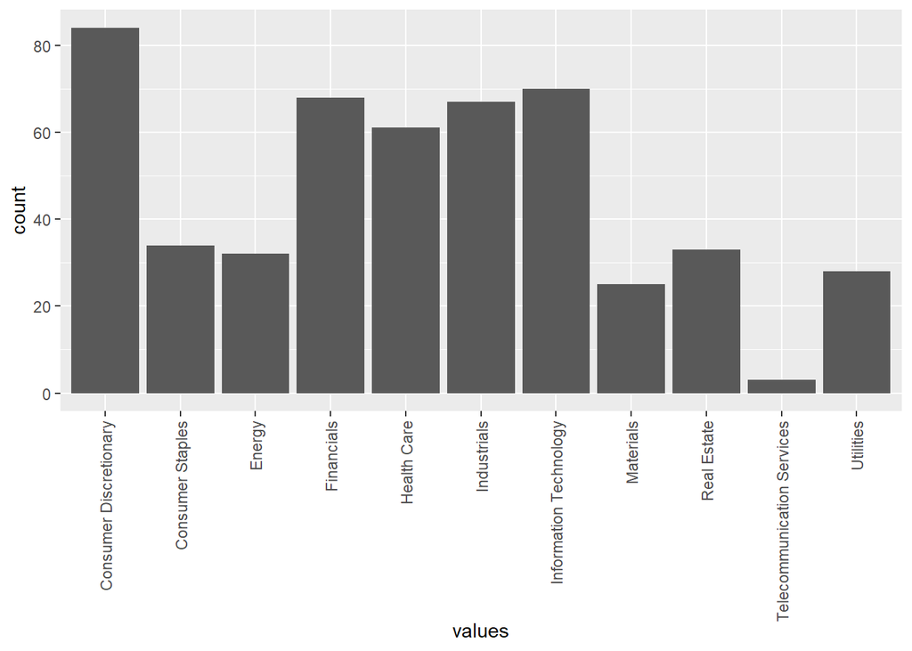

```r
#Number of companies by sector in snp 500
ggplot(snp_sector_data, aes(x=values)) + geom_bar() + theme(axis.text.x=element_text(angle=90,hjust=1,vjust=0.5))
```

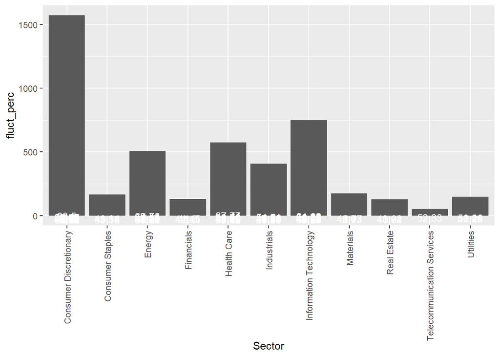

```r
#Sectors which experienced most fluctuations
ggplot(arrange(snp_data, desc(fluct_perc)) %>% top_n(100), aes(x=Sector, y=fluct_perc)) + geom_col() + theme(axis.text.x=element_text(angle=90,hjust=1,vjust=0.5)) + geom_text(aes(label=round(fluct_perc,2)), vjust=1.6, color="white", size=3.5)
```

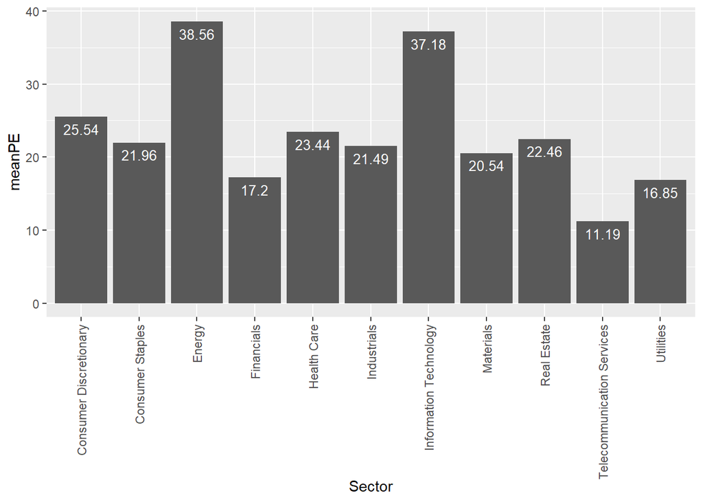

```r
#Highest PE sectors
ggplot(pe_data, aes(x=Sector, y=meanPE)) + geom_col() + theme(axis.text.x=element_text(angle=90,hjust=1,vjust=0.5)) + geom_text(aes(label=round(meanPE,2)), vjust=1.6, color="white", size=3.5)
```

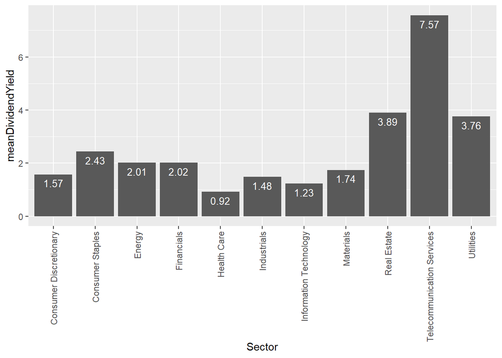

```r
#Highest dividend yield sectors
ggplot(yield_data, aes(x=Sector, y=meanDividendYield)) + geom_col() + theme(axis.text.x=element_text(angle=90,hjust=1,vjust=0.5))+ geom_text(aes(label=round(meanDividendYield,2)), vjust=1.6, color="white", size=3.5)
```

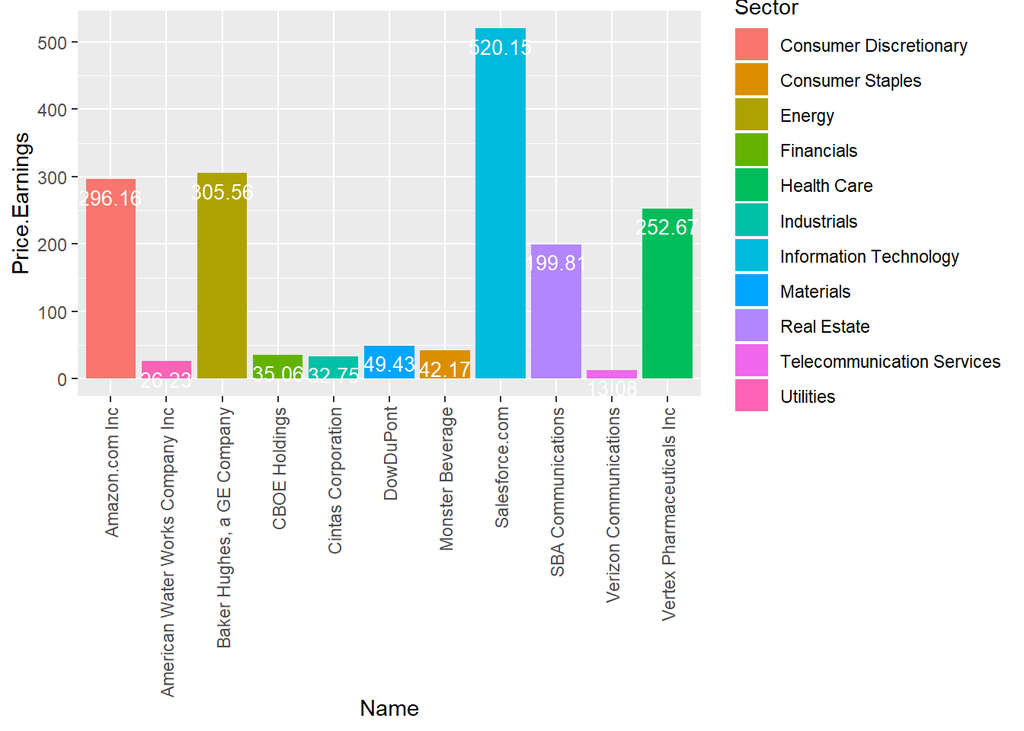

```r
#Print the premium stocks in each sector
ggplot(premium_stocks, aes(x=Name, y=Price.Earnings, fill=Sector)) + geom_col() + theme(axis.text.x=element_text(angle=90,hjust=1,vjust=0.5)) + geom_text(aes(label=round(Price.Earnings,2)), vjust=1.6, color="white", size=3.5)
```

## Observations

```
1.    Maximum number of companies in the SnP 500 are from 'consumer discretionary' sector
2.   'Consumer discretionary' sector is the one which experienced the most fluctuations in its stock prices
3.   'Telecommunication services' sector is the sector which experienced the least fluctuations in stock prices
4.   'Information Technology' and 'Energy' sector companies have the highest PE(price/Earning) ratio amongst all sectors
5.   'Telecommunication Services' sector offers the highest divident yield amongst all the sectors and 'Healthcare' offers the least
```